# Projet Analyse de Donnée

Chiheb Guesmi

2024-12-26

# 1 Introduction

Ce rapport explore les données collectées sur l’impact des séries dans la vie quotidienne à travers trois analyses principales :

**I/ Analyse en Composantes Principales (ACP)**

**II/ Analyse des Correspondances Multiples (ACM)**

**III/ Analyse Factorielle des Correspondances (AFC)**

# 2 Analyse en Composantes Principales (ACP)

## 2.1 1ere ACP : analyse d’impact des séries sur le mood :

**L’objectif principal de cette ACP est de :

Réduire la dimensionnalité des données : Identifier les dimensions les plus importantes (composantes principales) qui expliquent la majorité de la variance des réponses. Découvrir des relations entre les variables : Mettre en évidence les corrélations ou associations entre les séries et leur impact perçu sur l’humeur. Simplifier l’interprétation des données : Regrouper des variables ou questions similaires et interpréter leur contribution commune au phénomène étudié. Identifier des profils ou tendances : Comprendre comment les séries influencent différemment l’humeur des individus (positivement, négativement, ou de manière neutre)**

```r
library(tidyverse)
library(FactoMineR)
library(factoextra)
data <- read.csv("The Series Effect_ Uncover How Your Favorite Shows Shape Your Life  (Responses) - Form Responses 1.csv", stringsAsFactors = TRUE)
```

**Extraction des données :**

```r
likert_data <- data %>%
  select(starts_with("Influence.on.mood.and.well.being..On.a.scale.from.1.to.5")) %>%
  na.omit()
colnames(likert_data) <- gsub(".*\\.\\.\\.([A-Za-z0-9\\.]+)$", "\\1", colnames(likert_data))

# Convert columns to numeric
likert_data <- likert_data %>% mutate(across(everything(), as.numeric))

# Show the first few rows
head(likert_data)
```

```
##   Friends. How.I.Met.Your.Mother. The.Big.Bang.Theory. Suits. Breaking.Bad.
## 1        5                      5                    4      4             5
## 2        5                      2                    1      1             1
## 3        4                      2                    1      1             2
## 4        1                      1                    1      3             1
## 5        1                      5                    3      5             1
## 7        4                      4                    4      1             4
##   Game.of.Thrones. The.Office..US.. Stranger.Things. The.Crown. Lost.
## 1                3                4                4          3     2
## 2                1                4                4          1     1
## 3                1                1                1          1     1
## 4                2                3                2          2     3
## 5                5                2                1          2     3
## 7                4                4                4          4     4
##   La.Casa.de.Papel..Money.Heist.. Peaky.Blinders. Sex.Education.
## 1                               4               4              2
## 2                               1               2              1
## 3                               2               2              1
## 4                               4               1              1
## 5                               1               3              3
## 7                               4               4              1
##   The.good.Doctor. Sherlock. Bridgerton. Emily.in.Paris. Dark.
## 1                4         5           2               1     3
## 2                1         4           1               1     1
## 3                1         1           3               4     3
## 4                3         1           1               4     2
## 5                2         4           2               3     3
## 7                2         4           4               1     2
```

```r
summary(likert_data)
```

```
##     Friends.     How.I.Met.Your.Mother. The.Big.Bang.Theory.     Suits.
##  Min.   :1.000   Min.   :1.000          Min.   :1.000        Min.   :1.000
##  1st Qu.:1.000   1st Qu.:1.000          1st Qu.:1.000        1st Qu.:1.000
##  Median :3.000   Median :2.500          Median :2.000        Median :3.000
##  Mean   :2.625   Mean   :2.562          Mean   :2.333        Mean   :2.667
##  3rd Qu.:4.000   3rd Qu.:4.000          3rd Qu.:3.000        3rd Qu.:4.000
##  Max.   :5.000   Max.   :5.000          Max.   :5.000        Max.   :5.000
##  Breaking.Bad.   Game.of.Thrones. The.Office..US.. Stranger.Things.
##  Min.   :1.000   Min.   :1.000    Min.   :1.000    Min.   :1.000
##  1st Qu.:2.000   1st Qu.:1.750    1st Qu.:2.000    1st Qu.:2.000
##  Median :3.000   Median :3.000    Median :3.000    Median :2.000
##  Mean   :3.021   Mean   :2.833    Mean   :2.854    Mean   :2.771
##  3rd Qu.:4.250   3rd Qu.:4.000    3rd Qu.:4.000    3rd Qu.:4.000
##  Max.   :5.000   Max.   :5.000    Max.   :5.000    Max.   :5.000
##    The.Crown.        Lost.     La.Casa.de.Papel..Money.Heist.. Peaky.Blinders.
##  Min.   :1.000   Min.   :1.0   Min.   :1.000                   Min.   :1.000
##  1st Qu.:1.000   1st Qu.:1.0   1st Qu.:1.000                   1st Qu.:2.000
##  Median :2.000   Median :3.0   Median :3.000                   Median :3.000
##  Mean   :2.438   Mean   :2.5   Mean   :2.812                   Mean   :3.208
##  3rd Qu.:3.000   3rd Qu.:4.0   3rd Qu.:4.000                   3rd Qu.:5.000
##  Max.   :5.000   Max.   :5.0   Max.   :5.000                   Max.   :5.000
##  Sex.Education.  The.good.Doctor.   Sherlock.      Bridgerton.
##  Min.   :1.000   Min.   :1.000    Min.   :1.000   Min.   :1.000
##  1st Qu.:1.000   1st Qu.:1.750    1st Qu.:1.000   1st Qu.:1.000
##  Median :2.000   Median :3.000    Median :2.500   Median :2.000
##  Mean   :2.125   Mean   :2.667    Mean   :2.667   Mean   :2.292
##  3rd Qu.:3.000   3rd Qu.:4.000    3rd Qu.:4.000   3rd Qu.:3.000
##  Max.   :5.000   Max.   :5.000    Max.   :5.000   Max.   :5.000
##  Emily.in.Paris.     Dark.
##  Min.   :1.00    Min.   :1
##  1st Qu.:1.00    1st Qu.:2
##  Median :2.00    Median :3
##  Mean   :2.25    Mean   :3
##  3rd Qu.:3.00    3rd Qu.:4
##  Max.   :5.00    Max.   :5
```

**Réalisation de l’ACP**

```r
# Perform PCA
res.pca=PCA(likert_data,ncp = 5,quanti.sup = 11:12,quali.sup = 13,graph = F)
```

```r
summary(res.pca)
```

```
##
## Call:
## PCA(X = likert_data, ncp = 5, quanti.sup = 11:12, quali.sup = 13,
##      graph = F)
##
##
## Eigenvalues
##                        Dim.1   Dim.2   Dim.3   Dim.4   Dim.5   Dim.6   Dim.7
## Variance               4.068   1.856   1.597   1.177   1.066   0.950   0.816
## % of var.             27.118  12.372  10.645   7.850   7.110   6.335   5.440
## Cumulative % of var.  27.118  39.491  50.136  57.985  65.095  71.431  76.871
##                        Dim.8   Dim.9  Dim.10  Dim.11  Dim.12  Dim.13  Dim.14
## Variance               0.727   0.642   0.603   0.483   0.334   0.301   0.234
## % of var.              4.846   4.282   4.019   3.219   2.227   2.008   1.559
## Cumulative % of var.  81.716  85.998  90.017  93.236  95.463  97.471  99.030
##                       Dim.15
## Variance               0.145
## % of var.              0.970
## Cumulative % of var. 100.000
##
## Individuals (the 10 first)
##                                     Dist    Dim.1    ctr   cos2    Dim.2    ctr
## 1                               |  3.981 |  3.081  4.860  0.599 | -1.955  4.288
## 2                               |  4.319 | -1.687  1.458  0.153 | -2.197  5.420
## 3                               |  4.036 | -2.964  4.499  0.539 |  0.174  0.034
## 4                               |  3.231 | -1.890  1.830  0.342 |  1.108  1.379
## 5                               |  3.868 |  0.191  0.019  0.002 |  0.201  0.045
## 7                               |  3.733 |  2.294  2.695  0.378 | -1.244  1.737
## 8                               |  4.355 | -3.922  7.877  0.811 | -0.856  0.822
## 9                               |  3.588 |  1.258  0.811  0.123 |  1.697  3.231
## 11                              |  2.999 | -0.001  0.000  0.000 |  1.024  1.176
## 12                              |  4.322 | -3.193  5.222  0.546 | -0.435  0.213
##                                   cos2    Dim.3    ctr   cos2
## 1                                0.241 | -0.711  0.660  0.032 |
## 2                                0.259 | -0.064  0.005  0.000 |
## 3                                0.002 |  1.387  2.512  0.118 |
## 4                                0.118 |  0.836  0.912  0.067 |
## 5                                0.003 |  1.223  1.952  0.100 |
## 7                                0.111 |  0.116  0.018  0.001 |
## 8                                0.039 | -0.273  0.097  0.004 |
```

[output cut: 34 more lines]

```
## Peaky.Blinders.                 |
##
## Supplementary categories
##                                     Dist    Dim.1   cos2 v.test    Dim.2   cos2
## Sex.Education..1                |  1.107 | -0.919  0.688 -2.873 | -0.529  0.229
## Sex.Education..2                |  1.244 |  0.777  0.391  1.526 |  0.708  0.324
## Sex.Education..3                |  1.776 |  0.129  0.005  0.166 | -0.114  0.004
## Sex.Education..4                |  3.060 |  1.384  0.205  0.981 |  1.113  0.132
## Sex.Education..5                |  1.721 |  1.223  0.505  1.571 |  0.267  0.024
##                                 v.test    Dim.3   cos2 v.test
## Sex.Education..1                -2.451 |  0.018  0.000  0.090 |
## Sex.Education..2                 2.058 | -0.063  0.003 -0.197 |
## Sex.Education..3                -0.217 |  1.065  0.360  2.184 |
## Sex.Education..4                 1.168 | -1.638  0.287 -1.854 |
## Sex.Education..5                 0.508 | -0.459  0.071 -0.942 |
```

**Composantes Principales**

```r
# Extract eigenvalues
eig_values <- res.pca$eig
# Check the structure of eig_values
#str(eig_values)


# Create summary data frame using indexing instead of $ operator
# Create the eigenvalue summary data frame
eigen_summary <- data.frame(
  Dimension = rownames(eig_values),  # Using row names as Dimension labels
  Variance = eig_values[, 1],  # Eigenvalues (1st column)
  `Percentage of Variance` = eig_values[, 2],  # Percentage of variance (2nd column)
  `Cumulative % of Variance` = eig_values[, 3]  # Cumulative percentage of variance (3rd column)
)

# Print the eigenvalue summary
print(eigen_summary)
```

```
##         Dimension  Variance Percentage.of.Variance Cumulative...of.Variance
## comp 1     comp 1 4.0677625             27.1184165                 27.11842
## comp 2     comp 2 1.8558439             12.3722925                 39.49071
## comp 3     comp 3 1.5967476             10.6449841                 50.13569
## comp 4     comp 4 1.1774547              7.8496977                 57.98539
## comp 5     comp 5 1.0664669              7.1097792                 65.09517
## comp 6     comp 6 0.9503047              6.3353648                 71.43053
## comp 7     comp 7 0.8160103              5.4400684                 76.87060
## comp 8     comp 8 0.7268471              4.8456474                 81.71625
## comp 9     comp 9 0.6422348              4.2815650                 85.99782
## comp 10   comp 10 0.6028439              4.0189590                 90.01677
## comp 11   comp 11 0.4829029              3.2193525                 93.23613
## comp 12   comp 12 0.3339937              2.2266245                 95.46275
## comp 13   comp 13 0.3012306              2.0082042                 97.47096
## comp 14   comp 14 0.2338756              1.5591707                 99.03013
## comp 15   comp 15 0.1454810              0.9698735                100.00000
```

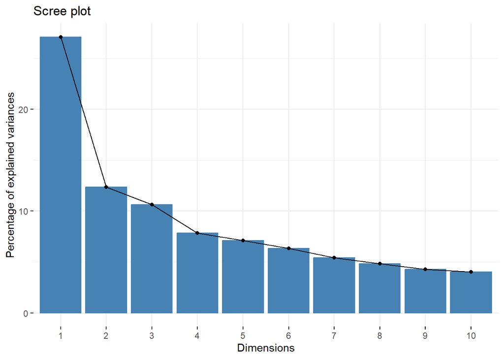

```r
fviz_screeplot(res.pca, ncp=10)
```

**Nombre D’axe à retenir** 1/Critère cumulatif :

Cela nécessiterait 6 composantes, puisque la variance cumulée à ce niveau est de 71.43%.

2/Critère du coude :

Selon le dernier plot , on peut opter pour 2 dimensions

3/Critère de Kaiser :

Kaiser recommande de retenir les composantes dont la variance (valeur propre) est supérieure à 1. Cela inclut les 5 premières composantes, car leurs variances sont respectivement de 4.07, 1.86, 1.60, 1.18, et 1.07.

Conclusion : Nous allons opter pour les 2 premiers axes.

```r
res.pca$var$coord
```

```
##                             Dim.1       Dim.2       Dim.3       Dim.4
## Friends.               0.41688364 -0.44938931  0.19268645  0.44945143
## How.I.Met.Your.Mother. 0.56061944 -0.52092866  0.17793279  0.01882599
## The.Big.Bang.Theory.   0.70528331 -0.06417666 -0.02725186 -0.25876843
## Suits.                 0.50326658  0.11992025  0.25619601 -0.45869320
## Breaking.Bad.          0.49354698 -0.13450344 -0.47350488 -0.04147393
## Game.of.Thrones.       0.30145945  0.41695678 -0.16901241 -0.08453179
## The.Office..US..       0.46666454 -0.12997507 -0.16388016 -0.47081807
## Stranger.Things.       0.71814698  0.24749169 -0.15932860  0.05250949
## The.Crown.             0.54582621 -0.31065588  0.46993136  0.11368789
## Lost.                  0.60450111  0.18991454  0.01212483  0.55321872
## The.good.Doctor.       0.70934223  0.26879039 -0.29353590  0.01641480
## Sherlock.              0.56425806 -0.35602730  0.04345103  0.02057862
## Bridgerton.            0.45961991  0.47566822  0.40871819 -0.14251650
## Emily.in.Paris.        0.02031233  0.54847126  0.73089635  0.07113112
## Dark.                  0.25383616  0.48505449 -0.38245549  0.34554461
##                              Dim.5
## Friends.               -0.32050996
## How.I.Met.Your.Mother.  0.23311476
## The.Big.Bang.Theory.   -0.06188513
## Suits.                  0.25743074
## Breaking.Bad.           0.30049574
## Game.of.Thrones.        0.41836195
## The.Office..US..       -0.38700555
## Stranger.Things.       -0.38779636
## The.Crown.              0.22120039
## Lost.                  -0.02833043
## The.good.Doctor.       -0.23702515
## Sherlock.               0.26922090
## Bridgerton.            -0.12531629
## Emily.in.Paris.         0.01981379
## Dark.                   0.28164495
```

**Intérprétation des axes**

Dim 1: **Popularité sociale et relationnelle** capture les séries qui influencent l’humour à travers des interactions sociales et des relations amicales(friends:0.4 ,how i met your mother: 0.5,the big bang theory:0.7).

Dim 2: **Emotions profondes et dramatiques** se concentre sur l’impact émotionnel plus intense, notamment des intrigues dramatiques ou romantiques(game of thrones:0.4 , Bridgerton:0.45,Emily in paris: 0.55).

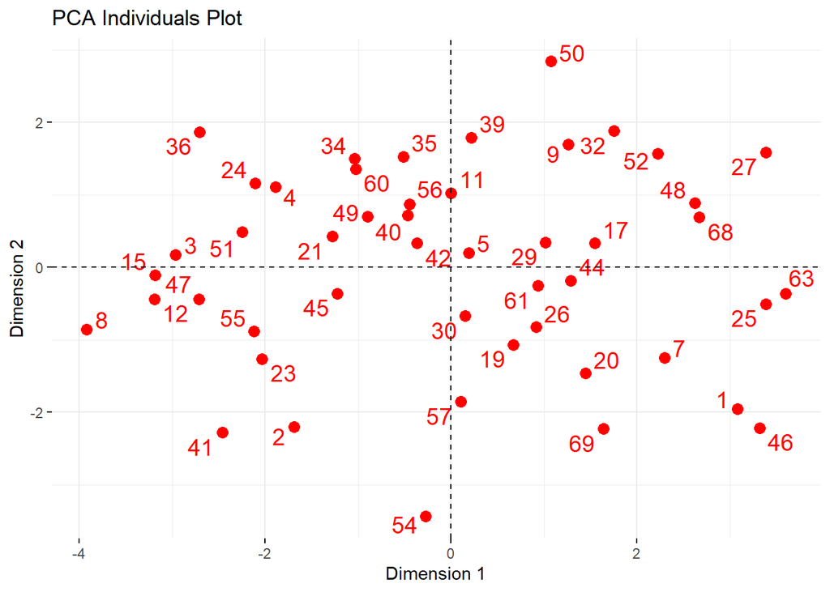

```r
# PCA individuals plot with enhancements
fviz_pca_ind(res.pca,
             col.ind = "red",        # Color of the individual points
             geom = c("point", "text"),  # Show both points and labels
             labelsize = 5,           # Adjust the size of the individual labels
             pointsize = 3,           # Adjust the size of the points
             repel = TRUE,            # Avoid overlapping labels
             title = "PCA Individuals Plot",  # Title of the plot
             xlab = "Dimension 1",    # X-axis label
             ylab = "Dimension 2")    # Y-axis label
```

```r
res.pca$var$cos2
```

```
##                               Dim.1       Dim.2        Dim.3        Dim.4
## Friends.               0.1737919677 0.201950756 0.0371280697 0.2020065914
## How.I.Met.Your.Mother. 0.3142941552 0.271366667 0.0316600769 0.0003544178
## The.Big.Bang.Theory.   0.4974245517 0.004118644 0.0007426641 0.0669611024
## Suits.                 0.2532772481 0.014380867 0.0656363957 0.2103994504
## Breaking.Bad.          0.2435886254 0.018091175 0.2242068716 0.0017200869
## Game.of.Thrones.       0.0908777979 0.173852956 0.0285651933 0.0071456242
## The.Office..US..       0.2177757958 0.016893518 0.0268567065 0.2216696545
## Stranger.Things.       0.5157350865 0.061252136 0.0253856035 0.0027572464
## The.Crown.             0.2979262479 0.096507074 0.2208354813 0.0129249361
## Lost.                  0.3654215875 0.036067531 0.0001470116 0.3060509545
## The.good.Doctor.       0.5031664028 0.072248272 0.0861633231 0.0002694458
## Sherlock.              0.3183871584 0.126755439 0.0018879916 0.0004234797
## Bridgerton.            0.2112504581 0.226260260 0.1670505558 0.0203109523
## Emily.in.Paris.        0.0004125906 0.300820718 0.5342094727 0.0050596358
## Dark.                  0.0644327982 0.235277861 0.1462722029 0.1194010747
##                               Dim.5
## Friends.               0.1027266374
## How.I.Met.Your.Mother. 0.0543424913
## The.Big.Bang.Theory.   0.0038297694
## Suits.                 0.0662705848
## Breaking.Bad.          0.0902976902
## Game.of.Thrones.       0.1750267220
## The.Office..US..       0.1497732926
## Stranger.Things.       0.1503860193
## The.Crown.             0.0489296143
## Lost.                  0.0008026130
## The.good.Doctor.       0.0561809223
## Sherlock.              0.0724798903
## Bridgerton.            0.0157041737
## Emily.in.Paris.        0.0003925862
## Dark.                  0.0793238787
```

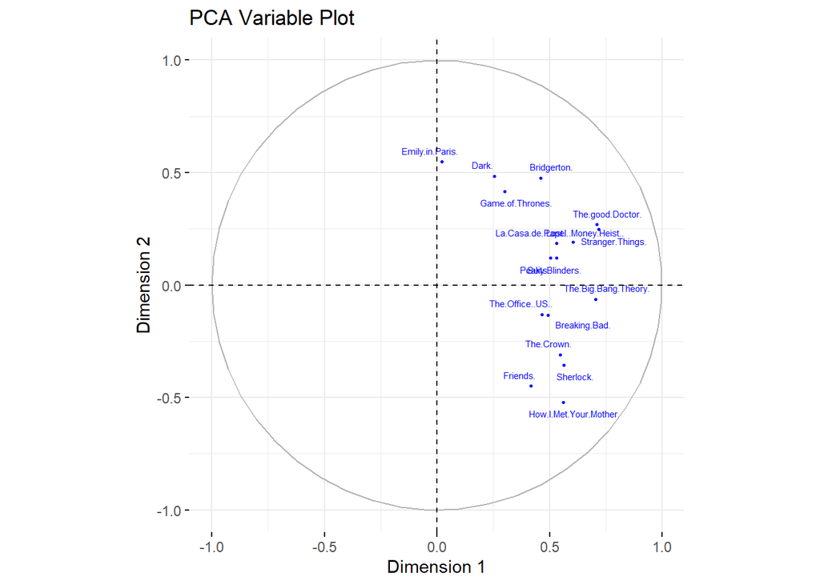

```r
library(factoextra)

# PCA variable plot with improvements
fviz_pca_var(res.pca,
             col.var = "blue",        # Color of the variable points
             geom = c("point", "text"),  # Show both points and labels
             labelsize = 2,           # Adjust the size of the variable labels
             pointsize = 0.5,           # Adjust the size of the points
             repel = TRUE,            # Avoid overlapping labels
             title = "PCA Variable Plot",  # Title of the plot
             xlab = "Dimension 1",    # X-axis label
             ylab = "Dimension 2")    # Y-axis label
```

**Interprétation**:

Les séries comme Emily in Paris et Dark sont fortement alignées sur le 2eme axe, ce qui montre qu’elles mettent en avant des éléments narratifs complexes, un drame intense ou des émotions profondes. À l’inverse, des séries comme Friends et How I Met Your Mother ont une faible intensité dramatique, renforçant leur association avec un humour léger et des situations quotidiennes.

The Big Bang Theory et Stranger Things dominent le quadrant “léger mais captivant”, combinant un ton accessible avec une touche d’éléments dramatiques.

Emily in Paris et Dark mettent en avant un style plus dramatique, moins centré sur l’humour, attirant un public à la recherche de contenu émotionnellement intense ou réfléchi.

## 2.2 2eme ACP : analyse d’impact des séries sur les différentes perspective de la vie (amour /famille/amis) :

```r
likert_data_2 <- data %>%
  select(starts_with("Change.in.perspective.on.love")) %>%
  na.omit()
colnames(likert_data_2) <- gsub(".*\\.\\.\\.([A-Za-z0-9\\.]+)$", "\\1", colnames(likert_data_2))

# Convert columns to numeric
likert_data_2 <- likert_data_2 %>% mutate(across(everything(), as.numeric))

# Show the first few rows
head(likert_data_2)
```

```
##   Friends. How.I.Met.Your.Mother. The.Big.Bang.Theory. Suits. Breaking.Bad.
## 2        5                      2                    1      1             1
## 3        4                      4                    1      1             1
## 4        1                      2                    3      3             2
## 5        3                      5                    4      5             1
## 7        4                      4                    4      3             4
## 8        1                      1                    1      1             1
##   Game.of.Thrones. The.Office..US.. Stranger.Things. The.Crown. Lost.
## 2                1                4                3          1     1
## 3                1                1                1          1     1
## 4                3                2                3          2     3
## 5                2                2                1          1     1
## 7                4                4                4          4     4
## 8                1                1                1          1     1
##   La.Casa.de.Papel..Money.Heist.. Peaky.Blinders. Sex.Education.
## 2                               1               1              1
## 3                               2               2              2
## 4                               2               2              1
## 5                               1               1              4
## 7                               4               4              3
## 8                               1               1              1
##   The.good.Doctor. Sherlock. Bridgerton. Emily.in.Paris. Dark.
## 2                1         4           1               1     1
## 3                2         2           4               4     3
## 4                3         1           1               4     1
## 5                3         2           2               5     2
## 7                4         4           4               1     2
## 8                1         1           1               1     1
```

```r
summary(likert_data_2)
```

```
##     Friends.     How.I.Met.Your.Mother. The.Big.Bang.Theory.     Suits.
##  Min.   :1.000   Min.   :1.000          Min.   :1.000        Min.   :1.000
##  1st Qu.:1.000   1st Qu.:1.000          1st Qu.:1.000        1st Qu.:1.000
##  Median :3.000   Median :3.000          Median :3.000        Median :3.000
##  Mean   :2.625   Mean   :2.875          Mean   :2.583        Mean   :2.708
##  3rd Qu.:4.000   3rd Qu.:4.000          3rd Qu.:3.250        3rd Qu.:4.000
##  Max.   :5.000   Max.   :5.000          Max.   :5.000        Max.   :5.000
##  Breaking.Bad.   Game.of.Thrones. The.Office..US.. Stranger.Things.
##  Min.   :1.000   Min.   :1.000    Min.   :1.000    Min.   :1.000
##  1st Qu.:1.000   1st Qu.:1.000    1st Qu.:1.000    1st Qu.:1.000
##  Median :3.000   Median :2.500    Median :3.000    Median :3.000
##  Mean   :2.833   Mean   :2.583    Mean   :2.688    Mean   :2.729
##  3rd Qu.:4.000   3rd Qu.:4.000    3rd Qu.:4.000    3rd Qu.:4.000
##  Max.   :5.000   Max.   :5.000    Max.   :5.000    Max.   :5.000
##    The.Crown.        Lost.       La.Casa.de.Papel..Money.Heist..
##  Min.   :1.000   Min.   :1.000   Min.   :1.000
##  1st Qu.:1.000   1st Qu.:1.000   1st Qu.:1.000
##  Median :3.000   Median :2.500   Median :2.000
##  Mean   :2.625   Mean   :2.438   Mean   :2.583
##  3rd Qu.:4.000   3rd Qu.:3.000   3rd Qu.:4.000
##  Max.   :5.000   Max.   :5.000   Max.   :5.000
##  Peaky.Blinders. Sex.Education.  The.good.Doctor.   Sherlock.      Bridgerton.
##  Min.   :1.000   Min.   :1.000   Min.   :1.000    Min.   :1.000   Min.   :1.0
##  1st Qu.:2.000   1st Qu.:1.000   1st Qu.:1.000    1st Qu.:1.000   1st Qu.:1.0
##  Median :3.000   Median :2.000   Median :3.000    Median :3.000   Median :2.0
##  Mean   :3.083   Mean   :2.417   Mean   :2.646    Mean   :2.646   Mean   :2.5
##  3rd Qu.:4.000   3rd Qu.:4.000   3rd Qu.:4.000    3rd Qu.:3.250   3rd Qu.:4.0
##  Max.   :5.000   Max.   :5.000   Max.   :5.000    Max.   :5.000   Max.   :5.0
##  Emily.in.Paris.     Dark.
##  Min.   :1.000   Min.   :1.000
##  1st Qu.:1.000   1st Qu.:1.000
##  Median :2.000   Median :2.000
##  Mean   :2.375   Mean   :2.542
##  3rd Qu.:4.000   3rd Qu.:4.000
##  Max.   :5.000   Max.   :5.000
```

```r
res2.pca = PCA(likert_data_2, ncp = 5, quanti.sup = 11:12, quali.sup = 13, graph = FALSE)
summary(res2.pca)
```

```
##
## Call:
## PCA(X = likert_data_2, ncp = 5, quanti.sup = 11:12, quali.sup = 13,
##      graph = FALSE)
##
##
## Eigenvalues
##                        Dim.1   Dim.2   Dim.3   Dim.4   Dim.5   Dim.6   Dim.7
## Variance               4.667   1.874   1.560   1.155   1.052   0.895   0.852
## % of var.             31.116  12.496  10.400   7.701   7.016   5.968   5.680
## Cumulative % of var.  31.116  43.613  54.012  61.713  68.729  74.697  80.377
##                        Dim.8   Dim.9  Dim.10  Dim.11  Dim.12  Dim.13  Dim.14
## Variance               0.723   0.588   0.419   0.397   0.320   0.230   0.142
## % of var.              4.821   3.919   2.794   2.650   2.132   1.536   0.945
## Cumulative % of var.  85.198  89.117  91.911  94.560  96.693  98.228  99.173
##                       Dim.15
## Variance               0.124
## % of var.              0.827
## Cumulative % of var. 100.000
##
## Individuals (the 10 first)
##                                     Dist    Dim.1    ctr   cos2    Dim.2    ctr
## 2                               |  4.312 | -2.381  2.530  0.305 |  1.419  2.239
## 3                               |  4.039 | -1.980  1.750  0.240 |  2.544  7.194
## 4                               |  2.903 | -1.016  0.461  0.123 | -1.079  1.293
## 5                               |  4.083 | -0.489  0.107  0.014 |  1.733  3.338
## 7                               |  3.646 |  2.968  3.933  0.663 | -0.279  0.087
## 8                               |  4.588 | -4.510  9.078  0.966 | -0.496  0.273
## 9                               |  3.749 |  1.159  0.600  0.096 |  2.474  6.802
## 10                              |  3.431 |  2.039  1.856  0.353 |  1.551  2.675
## 11                              |  2.559 |  1.612  1.160  0.397 |  0.544  0.329
## 12                              |  4.324 | -3.240  4.685  0.562 |  0.532  0.314
##                                   cos2    Dim.3    ctr   cos2
## 2                                0.108 |  0.193  0.050  0.002 |
## 3                                0.397 |  0.896  1.073  0.049 |
## 4                                0.138 | -0.204  0.055  0.005 |
## 5                                0.180 | -1.618  3.496  0.157 |
## 7                                0.006 | -0.285  0.108  0.006 |
## 8                                0.012 | -0.063  0.005  0.000 |
## 9                                0.436 | -0.328  0.144  0.008 |
```

[output cut: 34 more lines]

```
## Peaky.Blinders.                 |
##
## Supplementary categories
##                                     Dist    Dim.1   cos2 v.test    Dim.2   cos2
## Sex.Education..1                |  1.547 | -1.480  0.916 -3.970 | -0.293  0.036
## Sex.Education..2                |  1.204 | -0.103  0.007 -0.124 |  0.529  0.193
## Sex.Education..3                |  2.193 |  1.991  0.824  3.034 | -0.092  0.002
## Sex.Education..4                |  1.316 |  0.929  0.498  1.319 |  0.067  0.003
## Sex.Education..5                |  1.605 |  0.976  0.370  1.056 |  0.592  0.136
##                                 v.test    Dim.3   cos2 v.test
## Sex.Education..1                -1.239 | -0.164  0.011 -0.759 |
## Sex.Education..2                 1.002 |  0.639  0.281  1.325 |
## Sex.Education..3                -0.220 | -0.617  0.079 -1.626 |
## Sex.Education..4                 0.151 |  0.440  0.112  1.080 |
## Sex.Education..5                 1.012 |  0.294  0.034  0.550 |
```

```r
eig_values2 <- res2.pca$eig
# Check the structure of eig_values
str(eig_values2)
```

```
##  num [1:15, 1:3] 4.67 1.87 1.56 1.16 1.05 ...
##  - attr(*, "dimnames")=List of 2
##   ..$ : chr [1:15] "comp 1" "comp 2" "comp 3" "comp 4" ...
##   ..$ : chr [1:3] "eigenvalue" "percentage of variance" "cumulative percentage of variance"
```

```r
# Create summary data frame using indexing instead of $ operator
# Create the eigenvalue summary data frame
eigen_summary2 <- data.frame(
  Dimension = rownames(eig_values2),  # Using row names as Dimension labels
  Variance = eig_values2[, 1],  # Eigenvalues (1st column)
  `Percentage of Variance` = eig_values2[, 2],  # Percentage of variance (2nd column)
  `Cumulative % of Variance` = eig_values2[, 3]  # Cumulative percentage of variance (3rd column)
)

# Print the eigenvalue summary
print(eigen_summary2)
```

```
##         Dimension  Variance Percentage.of.Variance Cumulative...of.Variance
## comp 1     comp 1 4.6674683             31.1164553                 31.11646
## comp 2     comp 2 1.8744548             12.4963654                 43.61282
## comp 3     comp 3 1.5599252             10.3995016                 54.01232
## comp 4     comp 4 1.1551479              7.7009857                 61.71331
## comp 5     comp 5 1.0523583              7.0157217                 68.72903
## comp 6     comp 6 0.8952017              5.9680115                 74.69704
## comp 7     comp 7 0.8519749              5.6798324                 80.37687
## comp 8     comp 8 0.7231801              4.8212006                 85.19807
## comp 9     comp 9 0.5878551              3.9190340                 89.11711
## comp 10   comp 10 0.4190261              2.7935073                 91.91062
## comp 11   comp 11 0.3974528              2.6496852                 94.56030
## comp 12   comp 12 0.3198414              2.1322760                 96.69258
## comp 13   comp 13 0.2303883              1.5359220                 98.22850
## comp 14   comp 14 0.1416874              0.9445829                 99.17308
## comp 15   comp 15 0.1240378              0.8269185                100.00000
```